# UVic Biology R Handbook

Geoffrey Osgood

March 6, 2021

Hey everyone! This is a little guide to R. The example data and the R markdown used to make this html (as well as a pdf version) can be found at the github for this website. Feel free to download and use as you need!

GitHub: https://github.com/gjosgood/RhandbookUVicBiology.github.io

If you are not sure how to use GitHub, you can download all the files for your own use by clicking the green “Code” Button and clicking “Download ZIP.” That will give you all the code and data from the GitHub!

# Basic R facts

R works mainly through vectors, data frames, functions, and variables.

Vectors are a single column (ie from a matrix) containing the same “type” of data (ie numeric, categorical)

Data frames are columns put together into a table (ie your raw data and explanatory variables). Different columns can be different data types. Most often, you will upload and save your data into a data frame in R.

Functions are the operations you perform on your data, such as statistical tests. They are denoted with “()” after the function name. You put arguments for the function in the brackets (eg the data for which you want the mean).

## Variables

Variables are objects where you “put your work”, such as store or name vectors or data frames in R, or save the output of functions and statistical tests.

Variables are made using either the “=” sign or “<-”.

Example: lm.out<-lm(y~x, data=data) saves the output of a linear regression to a variable named lm.out.

Rules for naming variables:

1. Variable names MUST start with a letter (not underscore or number).
2. Variable names MUST contain ONLY letters, numbers, periods (“.”), or underscores ("_") and not symbols like %.

In the chunk of code below, “data” is the variable I create to hold my data frame, but I could call it anything I want (like “skunk”) as long as the name is not already used by something else and follows the rules.

## Packages

Many functions are built into R, but some researchers want to perform tests or make plots outside of base R functionality. Since R is open source, many researchers make “packages” that contain functions for different purposes.

To first install a package, use the function: install.packages(“package name”). Ensure the package name is in quotation marks. You only need to do this once.

To load a package for use: library(package) or require(package) with package name NOT in quotation marks. You need to do this everytime, or in every script, you want to use this package.

Example installing packages: vegan is an R package for community ecology analyses.

install.packages(“vegan”) #you will have to pick a “mirror” - choose “cloud” or one close to you.

to load the package: library(vegan)

# Read in, explore, and transform data

To make life easier, from Excel save your data as a CSV or TEXT file (both can be done using ‘Save As’). Ensure there are NO SPACES in column headers (use underscore "_" or periods “.” or capitals to differentiate words). Keep fancy symbols (ie @) out of your names too.

You can store data in a data frame or a vector.

## Import (read) data into R

```r
#Read in data
#data<-read.csv("filepath") - replace filepath with your actual filepath
#data is a variable. You could call it anything.

#example with my own filepath:
mammal_data<-read.csv("c:/Users/gjosg/Dropbox/R_Handbook_2020_UVic/Data/mammals.csv", header=TRUE, stringsAsFactors=FALSE) #header=TRUE indicates the first row is column names
#stringsAsFactors=F saves headaches later by ensuring "strings" (ie non-numbers) are read in as categorical variables rather than factors. Factors have special properties and it is annoying dealing with them until we want to explicitly. Many error messages will be avoided by reading in all strings as categorical variables instead of factors.

#Make a vector
vector_example<-c(145,15,1,5,45,87,83,23) #c() is a function to bring together elements of the same type - concatenation.
```

You can examine if a data frame read in correctly using head() to see the first six rows; tail to see the last; dim to see the number of rows and columns (in that order); names() for the column names; nrow() and ncol() for the number of rows and columns, respectively; and length() for the length of a vector or list. NOTE: length() will give number of elements in a vector or number of columns of a data frame (remember a data frame is a list of columns). Finally, use str() to see the structure of your data (what columns are there, what kinds of data are stored in each, ie numbers, strings)

Also use names() to rename columns

```r
#Take a look to make sure data read in correctly:
head(mammal_data) #see first six rows
```

```
##                 X    body brain
## 1      Arctic fox   3.385  44.5
## 2      Owl monkey   0.480  15.5
## 3 Mountain beaver   1.350   8.1
## 4             Cow 465.000 423.0
## 5       Grey wolf  36.330 119.5
## 6            Goat  27.660 115.0
```

```r
names(mammal_data) #access column names
```

```
## [1] "X"     "body"  "brain"
```

```r
dim(mammal_data) #number of rows, columns in data frame
```

```
## [1] 62  3
```

```r
nrow(mammal_data) #number of rows
```

```
## [1] 62
```

```r
ncol(mammal_data) #number of columns
```

```
## [1] 3
```

```r
length(vector_example) #number of elements in my vector
```

```
## [1] 8
```

```r
str(mammal_data) # how many columns, how many elements in each column, and the type of data in each column.
```

```
## 'data.frame':    62 obs. of  3 variables:
##  $ X    : chr  "Arctic fox" "Owl monkey" "Mountain beaver" "Cow" ...
##  $ body : num  3.38 0.48 1.35 465 36.33 ...
##  $ brain: num  44.5 15.5 8.1 423 119.5 ...
```

```r
names(mammal_data)<-c("Species", "Brain_size", "Body_size") #rename the three columns of mammal_data
```

To access or reference a single column, it is easiest to use the "$" operator: For example: mammal_data$Brain_size gives me the brain size column in the mammals data frame.

```r
#Retrieve the first six rows (head) of the brain column of mammal_data
head(mammal_data$Brain_size)
```

```
## [1]   3.385   0.480   1.350 465.000  36.330  27.660
```

## Data types

The basic data types in R are: factors, characters, numeric, integar, and Boolean.

Factors and characters represent all data that are NOT numbers — a type of data called strings. Strings can be identifid as being within quotation marks (" ").

A factor is used in statistics to represent strings (categorical variables) that have distinct and repeated levels of manipulation, such as a high, medium, and low food treatments in a feeding experiment. If the categorical variable is not composed of a few particular levels that are repeated many times, then the variable is called a “character.” Statistical tests are run using factors (when you have categorical explanatory variables), but R will convert characters automatically to factors when needed, so it is always better to work with characters first as they are less error prone while exploring or cleaning data.

Numeric data are numbers you intend to use in analyses as continuous variables. Integers are integers.

Boolean is a special data type for the output of logical statements and takes the form TRUE or FALSE. If you see TRUE or FALSE in all caps in a data column, those data are Boolean. You can create Boolean data using logical statements (x > y). See an example in the code chunk below.

You can use str() on your data frame to see how the data in each of your columns are classified. You can use class() to get the class of a single vector or column.

Use as.character() to change a vector or column to a character.

Use as.factor() to change a vector or column to a factor.

Use as.numeric() to change a vector or column to numeric. NOTE: Factors are assigned numbers that represent the order of the levels (ie 1 represents the first level). When you use as.numeric on a factor, you change the vector or column to these numbers. For instance, the string “3” (notice the "“) can be turned to the number 3 using as.numeric(”3“), but only if it is classified as a character in R first. Using as.numeric() after as.factor(”3“) will give 1 (since”3" is the only element given, it is automatically assigned the first level, ie 1). See code chunk below for this in action.

Use as.numeric on Boolean variables to change TRUE to 1 and FALSE to 0 - useful if you are counting how many TRUE statements you have. BUT you can also use mathematical operators on Boolean values and R will automatically turn them into numbers first (ie sum(x>5) will count how many times x is greater than 5).

You can also treat numbers as characters if the numbers do not mean something mathematically but represent a categorical variable - month is an example.

```r
#Examine structure of the data:
str(mammal_data)
```

```
## 'data.frame':    62 obs. of  3 variables:
##  $ Species   : chr  "Arctic fox" "Owl monkey" "Mountain beaver" "Cow" ...
##  $ Brain_size: num  3.38 0.48 1.35 465 36.33 ...
##  $ Body_size : num  44.5 15.5 8.1 423 119.5 ...
```

```r
#tells me it is a data frame of 62 rows in 3 columns.
#Species in mammal_data is a 'character'
#body and brain are numeric

#Use as.factor() to change a variable to a factor
mammal_data$Species<-as.factor(mammal_data$Species) # $ is how I access a specific column (in this case Species).

class(mammal_data$Species) # tells me what "class" Species is - should be a factor now.
```

```
## [1] "factor"
```

```r
#Use as.character() to change a variable to a character again
mammal_data$Species<-as.character(mammal_data$Species)

class(mammal_data$Species) #Should be character now.
```

```
## [1] "character"
```

```r
#Numbers to character
mammal_data$Brain_size<-as.character(mammal_data$Brain_size)
class(mammal_data$Brain_size) #Should be character now.
```

```
## [1] "character"
```

```r
mammal_data$Brain_size<-as.numeric(mammal_data$Brain_size)
class(mammal_data$Brain_size) #Should be character now.
```

```
## [1] "numeric"
```

```r
#Numbers representing level order when using as.numeric on a factor. Default order is alphabetical (ie so alphabetically first factor level will be assigned "1").
head(as.numeric(as.factor(mammal_data$Brain_size)))
```

```
## [1] 31 14 22 56 44 42
```

```r
#Some packages include example data accessed with the data() function. The mammals data set above is an example from the MASS package.
library(MASS) #access the data
data(mammals)

#The rows are named based on the species. I can access these names with
head(rownames(mammals)) #first six row names
```

```
## [1] "Arctic fox"      "Owl monkey"      "Mountain beaver" "Cow"
## [5] "Grey wolf"       "Goat"
```

```r
#Boolean examples
#What if I wanted a column indicating if Brain size was greater than 4?
mammal_data$isBrainBig<-mammal_data$Brain_size > 4
head(mammal_data$isBrainBig)
```

```
## [1] FALSE FALSE FALSE  TRUE  TRUE  TRUE
```

```r
#how many species have a brain size greater than 4?
sum(mammal_data$isBrainBig)
```

```
## [1] 27
```

```r
#or
sum(mammal_data$Brain_size > 4)
```

```
## [1] 27
```

```r
#Using as.numeric on factors
numberString <- as.factor(c("5", "2", "99", "8", "15")) #use c() to put all these strings together in a vector, then apply as.factor to all of them.

#using as.numeric will return factor levels (alphabetically first will get factor level of 1)
as.numeric(numberString)
```

```
## [1] 3 2 5 4 1
```

```r
#convert to character to ensure as.numeric will produce numbers
as.numeric(as.character(numberString))
```

```
## [1]  5  2 99  8 15
```

## Exploring categorical variables, including factor levels

You can use unique() to see how many unique/distinct values or characters exist in a column or vector.

You can use table() to generate frequencies (how many observations of each level of a categorical variable).

You can use levels() to see what levels a factor has and what level order each level has. Automatically, R assigns 1 to the alphabetically first level, but you can change the order yourself using the levels argument in the factor() function. See code chunk for an example.

```r
#what unique levels exist for a grouping variable:
unique(mammal_data$Species)
```

```
##  [1] "Arctic fox"                "Owl monkey"
##  [3] "Mountain beaver"           "Cow"
##  [5] "Grey wolf"                 "Goat"
##  [7] "Roe deer"                  "Guinea pig"
##  [9] "Verbet"                    "Chinchilla"
## [11] "Ground squirrel"           "Arctic ground squirrel"
## [13] "African giant pouched rat" "Lesser short-tailed shrew"
## [15] "Star-nosed mole"           "Nine-banded armadillo"
## [17] "Tree hyrax"                "N.A. opossum"
## [19] "Asian elephant"            "Big brown bat"
## [21] "Donkey"                    "Horse"
## [23] "European hedgehog"         "Patas monkey"
## [25] "Cat"                       "Galago"
## [27] "Genet"                     "Giraffe"
## [29] "Gorilla"                   "Grey seal"
```

[output cut: 16 more lines]

```r
#how many observations are there for each level of a categorical variable:
table(mammal_data$Species)
```

```
##
##          African elephant African giant pouched rat                Arctic fox
##                         1                         1                         1
##    Arctic ground squirrel            Asian elephant                    Baboon
##                         1                         1                         1
##             Big brown bat           Brazilian tapir                       Cat
##                         1                         1                         1
##                Chimpanzee                Chinchilla                       Cow
##                         1                         1                         1
##           Desert hedgehog                    Donkey          E. American mole
##                         1                         1                         1
##                   Echidna         European hedgehog                    Galago
##                         1                         1                         1
##                     Genet           Giant armadillo                   Giraffe
##                         1                         1                         1
##                      Goat            Golden hamster                   Gorilla
##                         1                         1                         1
##                 Grey seal                 Grey wolf           Ground squirrel
##                         1                         1                         1
##                Guinea pig                     Horse                     Human
##                         1                         1                         1
##                    Jaguar                  Kangaroo Lesser short-tailed shrew
##                         1                         1                         1
##          Little brown bat                  Mole rat           Mountain beaver
##                         1                         1                         1
##                     Mouse                Musk shrew              N.A. opossum
##                         1                         1                         1
##     Nine-banded armadillo                     Okapi                Owl monkey
##                         1                         1                         1
##              Patas monkey                 Phalanger                       Pig
##                         1                         1                         1
##                    Rabbit                   Raccoon                       Rat
##                         1                         1                         1
##                   Red fox             Rhesus monkey              Rock hyrax-a
##                         1                         1                         1
##              Rock hyrax-b                  Roe deer                     Sheep
##                         1                         1                         1
##                Slow loris           Star-nosed mole                    Tenrec
##                         1                         1                         1
##                Tree hyrax                Tree shrew                    Verbet
##                         1                         1                         1
##             Water opossum     Yellow-bellied marmot
##                         1                         1
```

```r
#factor levels example
colours<-as.factor(c("red", "blue", "green")) #use c() to put the strings together.

levels(colours) # the levels and their order. Notice "blue" is first
```

```
## [1] "blue"  "green" "red"
```

```r
colours<-factor(colours, levels=c("red", "green", "blue"))
levels(colours) #now "red" is first and "blue" is last
```

```
## [1] "red"   "green" "blue"
```

## Transform data - log, power, trigonometry

To transform data, take the function you want (ie log) and apply it to the column of data you wish to transform. You can either replace the column with the transformed data, or make a new column using the $ symbol, which is used to access columns in a data frame.

You can save transformed data into in the same column, but I recommend making a new column.

```r
library(MASS) #access the data
data(mammals)

ncol(mammals) # 2 columns
```

```
## [1] 2
```

```r
#Transform data

###################
#Log-transform#####
###################
mammals$log_body <- log(mammals$body) #make a new column and put log-transformed body values into it. This uses base "e" (ie ln transform) by default

ncol(mammals) # a new column has been added
```

```
## [1] 3
```

```r
mammals$log10_body <- log(mammals$body, base=10) #make a new column and put log-transformed body values into it. This uses base "e" (ie ln transform) by default


#Exponential function to reverse ln-transformation
mammals$undo_log <- exp(mammals$log_body) #make a new column and put exponential transformed log-body values into it.

#Exponential function to reverse log10-transformation
mammals$undo_log10 <- 10^(mammals$log10_body) #make a new column and put exponential transformed log-body values into it.

#####################
#Powers:#############
#####################

#Square root:
mammals$sqrt_brain <- sqrt(mammals$brain) #make a new column and put square-root transformed brain values into it.

mammals$brain_squared <- mammals$brain^2 #make a new column and put squared transformed brain values into it.
mammals$brain_cubed <- mammals$brain^3 #make a new column and put cubed transformed brain values into it.

mammals$brain_cubic_root <- mammals$brain^(1/3) #make a new column and put cubic root of brain values into it.

mammals$arcsine_brain <- asin(mammals$brain) #make a new column and put cubic root
############################
#Trigonometry functions:####
############################
#Making example data:##
invasive_data<-data.frame(Treatment=rep(c("Pesticide", "Control"), rep(10,2)), Number_of_Quadrats=c(15,15,11,14,15,15,13,14,15,15,12,10,15,15,15,14,15,15,13,15), InvasiveSpecies=c(4,3,5,4,2,1,1,8,6,3,4,7,8,10,14,6,6,5,7,6), Precip=c(383,654,1203,1200,784,489,964,451,478,1478,547,964,1577,621,573,871,654,982,784,1482))
##################

#Transformations:
invasive_data$ProportionInvasive<-invasive_data$InvasiveSpecies/invasive_data$Number_of_Quadrats #calculate proportions of species at a site that are invasive

#Sine, cosine, and tangent
invasive_data$sine_prop<-sin(invasive_data$ProportionInvasive)
invasive_data$cosine_prop<-cos(invasive_data$ProportionInvasive)
invasive_data$tangent_prop<-tan(invasive_data$ProportionInvasive)

#Arcsine, arc-cosine, arc-tangent
invasive_data$arcsine_prop<-asin(invasive_data$ProportionInvasive)
invasive_data$arc_cosine_prop<-acos(invasive_data$ProportionInvasive)
invasive_data$arc_tangent_prop<-atan(invasive_data$ProportionInvasive)
```

## Subset and order data frames

Use “[]” to access specific rows, columns, or cells.

Use subset() to subset data based on levels of a categorical variable (eg. get only the data in a “low” treatment).

You can use order() to re-order data frames based on alphabetical or numerical order.

```r
#Example data set:
#Make a data frame holding Shannon diversity indices for sites within two MPAs, one column to hold the diversity index, the other to identify the MPA.

#the shannon diversity held in separate objects called vectors
#A vector is a single column of data of one type
WhaleSanctuary=c(1.8816523, 1.8389828, 1.3239195, 0.6931472,  0.6615632,1.2299186, 1.9963156, 1.0045784, 0.3767702,2.0468186)

KelpMPA=c(1.3835889, 1.2442544, 1.0567522, 0.9973048, 1.9783942,1.1156818, 1.3214234, 1.9923252, 1.2984907, 1.3025272)

length(WhaleSanctuary) #length() tells me how many entries are in a list or vector
```

```
## [1] 10
```

```r
#You can also store them together in a data frame:
MPA_Data<-data.frame(MPA=c(rep("WhaleSanctuary", length(WhaleSanctuary)), rep("KelpMPA", length(KelpMPA))), ShannonDiversity=c(WhaleSanctuary, KelpMPA))
#makes a data frame with each row as an observation. One column identifies the MPA and the other column holds the Shannon diversity of that site.
#rep() replicates any text the specified number of times.
#so the MPA column repeats WhaleSanctuary for all the WhaleSanctuary numbers and then repeats KelpMPA for all the KelpMPA numbers

#Subsetting data frames:
#getting only the Kelp MPA data:
KelP_MPA<-subset(MPA_Data, MPA=="KelpMPA") # == sign means find something exactly equal to this - not this is not the same as the single = sign, which is used in function arguments or to assign things to objects.

#Retrieve cells from a data frame:
#[] is used to access data frames and matrices. In R: rows go before columns, so
MPA_Data[3,2] #will give me the value in the third row, second column of MPA_Data
```

```
## [1] 1.323919
```

```r
#If I want all of one row: leave the columns blank:
MPA_Data[2,] #gives me entire second row over all columns
```

```
##              MPA ShannonDiversity
## 2 WhaleSanctuary         1.838983
```

```r
#If I want an entire column:
MPA_Data[,2] #gives me entire second column
```

```
##  [1] 1.8816523 1.8389828 1.3239195 0.6931472 0.6615632 1.2299186 1.9963156
##  [8] 1.0045784 0.3767702 2.0468186 1.3835889 1.2442544 1.0567522 0.9973048
## [15] 1.9783942 1.1156818 1.3214234 1.9923252 1.2984907 1.3025272
```

```r
# $ is also used to access specific columns of a data frame (or parts of a list - a data frame is really a list of columns)
MPA_Data$MPA #gives me the MPA column
```

```
##  [1] "WhaleSanctuary" "WhaleSanctuary" "WhaleSanctuary" "WhaleSanctuary"
##  [5] "WhaleSanctuary" "WhaleSanctuary" "WhaleSanctuary" "WhaleSanctuary"
##  [9] "WhaleSanctuary" "WhaleSanctuary" "KelpMPA"        "KelpMPA"
## [13] "KelpMPA"        "KelpMPA"        "KelpMPA"        "KelpMPA"
## [17] "KelpMPA"        "KelpMPA"        "KelpMPA"        "KelpMPA"
```

The function order() orders rows from A to Z or smallest to largest. Put a negative size in the brackets to do the reverse or use the decreasing=TRUE argument.

```r
#Order rows with small diversity first
MPA_Data[order(MPA_Data$ShannonDiversity),]
```

```
##               MPA ShannonDiversity
## 9  WhaleSanctuary        0.3767702
## 5  WhaleSanctuary        0.6615632
## 4  WhaleSanctuary        0.6931472
## 14        KelpMPA        0.9973048
## 8  WhaleSanctuary        1.0045784
## 13        KelpMPA        1.0567522
## 16        KelpMPA        1.1156818
## 6  WhaleSanctuary        1.2299186
## 12        KelpMPA        1.2442544
## 19        KelpMPA        1.2984907
## 20        KelpMPA        1.3025272
## 17        KelpMPA        1.3214234
## 3  WhaleSanctuary        1.3239195
## 11        KelpMPA        1.3835889
## 2  WhaleSanctuary        1.8389828
## 1  WhaleSanctuary        1.8816523
## 15        KelpMPA        1.9783942
## 18        KelpMPA        1.9923252
## 7  WhaleSanctuary        1.9963156
## 10 WhaleSanctuary        2.0468186
```

```r
#Order sites with the largest diversity first
MPA_Data[order(-MPA_Data$ShannonDiversity),]
```

```
##               MPA ShannonDiversity
## 10 WhaleSanctuary        2.0468186
## 7  WhaleSanctuary        1.9963156
## 18        KelpMPA        1.9923252
## 15        KelpMPA        1.9783942
## 1  WhaleSanctuary        1.8816523
## 2  WhaleSanctuary        1.8389828
## 11        KelpMPA        1.3835889
## 3  WhaleSanctuary        1.3239195
## 17        KelpMPA        1.3214234
## 20        KelpMPA        1.3025272
## 19        KelpMPA        1.2984907
## 12        KelpMPA        1.2442544
## 6  WhaleSanctuary        1.2299186
## 16        KelpMPA        1.1156818
## 13        KelpMPA        1.0567522
## 8  WhaleSanctuary        1.0045784
## 14        KelpMPA        0.9973048
## 4  WhaleSanctuary        0.6931472
## 5  WhaleSanctuary        0.6615632
## 9  WhaleSanctuary        0.3767702
```

```r
#Order brain size based on species - alphabetical order
mammal_data[order(mammal_data$Species, decreasing=FALSE),]
```

```
##                      Species Brain_size Body_size isBrainBig
## 33          African elephant   6654.000   5712.00       TRUE
## 13 African giant pouched rat      1.000      6.60      FALSE
## 1                 Arctic fox      3.385     44.50      FALSE
## 12    Arctic ground squirrel      0.920      5.70      FALSE
## 19            Asian elephant   2547.000   4603.00       TRUE
## 47                    Baboon     10.550    179.50       TRUE
## 20             Big brown bat      0.023      0.30      FALSE
## 58           Brazilian tapir    160.000    169.00       TRUE
## 25                       Cat      3.300     25.60      FALSE
## 46                Chimpanzee     52.160    440.00       TRUE
## 10                Chinchilla      0.425      6.40      FALSE
## 4                        Cow    465.000    423.00       TRUE
## 48           Desert hedgehog      0.550      2.40      FALSE
## 21                    Donkey    187.100    419.00       TRUE
```

[output cut: 48 more lines]

```r
#Order brain size based on species - reverse alphabetical order
mammal_data[order(mammal_data$Species, decreasing=TRUE),]
```

```
##                      Species Brain_size Body_size isBrainBig
## 37     Yellow-bellied marmot      4.050     17.00       TRUE
## 34             Water opossum      3.500      3.90      FALSE
## 9                     Verbet      4.190     58.00       TRUE
## 61                Tree shrew      0.104      2.50      FALSE
## 17                Tree hyrax      2.000     12.30      FALSE
## 59                    Tenrec      0.900      2.60      FALSE
## 15           Star-nosed mole      0.060      1.00      FALSE
## 41                Slow loris      1.400     12.50      FALSE
## 44                     Sheep     55.500    175.00       TRUE
## 7                   Roe deer     14.830     98.20       TRUE
## 50              Rock hyrax-b      3.600     21.00      FALSE
## 31              Rock hyrax-a      0.750     12.30      FALSE
## 35             Rhesus monkey      6.800    179.00       TRUE
## 62                   Red fox      4.235     50.40       TRUE
```

[output cut: 48 more lines]

Reshaping data - when you have multiple response variables or levels, there are two ways to organize your data frame:

1. “wide” format with each variable as its own column.
2. “long” with the values for the variable in one column and an ID column indicating which variable or level the value represents.

Use the function melt() to change wide format to long and the function dcast() to turn long into wide format - in the reshape2 package.

Example: Ozone levels in different months, days, etc.

```r
#Example data set - ozone levels
#install.packages("mlbench")
library(mlbench)
data(Ozone)
Ozone_example<-Ozone[,c(1,2,4,5,6,8)] # I only want some columns for the example
names(Ozone_example)<-c("Month", "Day", "Ozone", "Pressure", "Wind", "Temperature")
head(Ozone_example) # it is currently in wide format, with ozone, pressure, wind, temperature each in their own column
```

```
##   Month Day Ozone Pressure Wind Temperature
## 1     1   1     3     5480    8          NA
## 2     1   2     3     5660    6          38
## 3     1   3     3     5710    4          40
## 4     1   4     5     5700    3          45
## 5     1   5     5     5760    3          54
## 6     1   6     6     5720    4          35
```

```r
dim(Ozone_example)
```

```
## [1] 366   6
```

```r
#Reshaping data frames
#install.packages("reshape2")
library(reshape2)

#Turn wide format into long
Ozone_long<-melt(Ozone_example, id.vars=c("Month", "Day")) # I want to take the climatic variables into one column, with a column identifying which climatic variable the value represents. I want Month and Day to still indicate the Month and Day of the measurements, hence why I put them in id.vars=c().
names(Ozone_long)<-c("Month", "Day", "Climatic_variable", "Climatic_value")
head(Ozone_long) #the four columns of climate variables have been collapased into 2, and the data frame is "longer."
```

```
##   Month Day Climatic_variable Climatic_value
## 1     1   1             Ozone              3
## 2     1   2             Ozone              3
## 3     1   3             Ozone              3
## 4     1   4             Ozone              5
## 5     1   5             Ozone              5
## 6     1   6             Ozone              6
```

```r
dim(Ozone_long)
```

```
## [1] 1464    4
```

```r
#Turn wide into long format - use dcast
Ozone_wide<-dcast(Ozone_long, Month+Day~Climatic_variable, value.vars=c("Climatic_value"))#I want to keep Month and Day as explanatory columns, but put each climatic variable back into its own column. The values placed in each column is specified by value.vars - in this case the Climatic_value.
head(Ozone_long)
```

```
##   Month Day Climatic_variable Climatic_value
## 1     1   1             Ozone              3
## 2     1   2             Ozone              3
## 3     1   3             Ozone              3
## 4     1   4             Ozone              5
## 5     1   5             Ozone              5
## 6     1   6             Ozone              6
```

```r
dim(Ozone_long)
```

```
## [1] 1464    4
```

# Summary statistics

## Read in example data

```r
#Example data used in ANOVA section
library(carData) #remember to install.packages(carData) before first use
data(Soils) #some packages have data sets saved in them. The data() function retrieves them - in this case loading a data frame called Soils
head(Soils)
```

```
##   Group Contour Depth Gp Block   pH     N Dens   P    Ca   Mg    K   Na Conduc
## 1     1     Top  0-10 T0     1 5.40 0.188 0.92 215 16.35 7.65 0.72 1.14   1.09
## 2     1     Top  0-10 T0     2 5.65 0.165 1.04 208 12.25 5.15 0.71 0.94   1.35
## 3     1     Top  0-10 T0     3 5.14 0.260 0.95 300 13.02 5.68 0.68 0.60   1.41
## 4     1     Top  0-10 T0     4 5.14 0.169 1.10 248 11.92 7.88 1.09 1.01   1.64
## 5     2     Top 10-30 T1     1 5.14 0.164 1.12 174 14.17 8.12 0.70 2.17   1.85
## 6     2     Top 10-30 T1     2 5.10 0.094 1.22 129  8.55 6.92 0.81 2.67   3.18
```

## Mean, range, standard deviation, standard error

```r
#Mean pH across all samples:
mean(Soils$pH)
```

```
## [1] 4.669375
```

```r
#Mean pH by Depth class:
aggregate(pH~Depth, data=Soils, FUN=mean) #aggregate runs a function for each level of a specified group (in this case depth classes)
```

```
##   Depth       pH
## 1  0-10 5.397500
## 2 10-30 5.004167
## 3 30-60 4.278333
## 4 60-90 3.997500
```

```r
#Standard deviation of pH across all samples:
sd(Soils$pH)
```

```
## [1] 0.6718549
```

```r
#Standard deviation of pH by depth:
aggregate(pH~Depth, data=Soils, FUN=sd)
```

```
##   Depth        pH
## 1  0-10 0.2487103
## 2 10-30 0.5968624
## 3 30-60 0.3306422
## 4 60-90 0.2032967
```

```r
#Variance of pH across all samples:
var(Soils$pH)
```

```
## [1] 0.451389
```

```r
#Variance of pH by depth:
aggregate(pH~Depth, data=Soils, FUN=var)
```

```
##   Depth         pH
## 1  0-10 0.06185682
## 2 10-30 0.35624470
## 3 30-60 0.10932424
## 4 60-90 0.04132955
```

```r
#Standard error of the mean
#There is no function for standard error in R, so we have to make our own using the standard error formula:
se<-function(x) {sd(x)/sqrt(length(x))}
#Standard error of the mean of pH across all samples:
se(Soils$pH)
```

```
## [1] 0.0969739
```

```r
#Standard error of the mean of pH by depth:
aggregate(pH~Depth, data=Soils, FUN=se)
```

```
##   Depth         pH
## 1  0-10 0.07179648
## 2 10-30 0.17229933
## 3 30-60 0.09544817
## 4 60-90 0.05868670
```

```r
#Can also get minimum, maximum, mean, and quartiles:
summary(Soils$pH)
```

```
##    Min. 1st Qu.  Median    Mean 3rd Qu.    Max.
##   3.740   4.058   4.545   4.669   5.140   6.670
```

```r
summary(Soils) #get summaries of all variables at once
```

```
##      Group          Contour     Depth          Gp     Block        pH
##  1      : 4   Depression:16   0-10 :12   D0     : 4   1:12   Min.   :3.740
##  2      : 4   Slope     :16   10-30:12   D1     : 4   2:12   1st Qu.:4.058
##  3      : 4   Top       :16   30-60:12   D3     : 4   3:12   Median :4.545
##  4      : 4                   60-90:12   D6     : 4   4:12   Mean   :4.669
##  5      : 4                              S0     : 4          3rd Qu.:5.140
##  6      : 4                              S1     : 4          Max.   :6.670
##  (Other):24                              (Other):24
##        N                Dens             P               Ca
##  Min.   :0.03000   Min.   :0.780   Min.   : 79.0   Min.   : 3.820
##  1st Qu.:0.05075   1st Qu.:1.127   1st Qu.:108.8   1st Qu.: 5.040
##  Median :0.08450   Median :1.400   Median :131.0   Median : 7.305
##  Mean   :0.10194   Mean   :1.316   Mean   :166.2   Mean   : 8.029
##  3rd Qu.:0.12925   3rd Qu.:1.502   3rd Qu.:214.2   3rd Qu.: 9.735
##  Max.   :0.29800   Max.   :1.600   Max.   :445.0   Max.   :16.350
##
##        Mg               K                Na             Conduc
##  Min.   : 5.150   Min.   :0.1400   Min.   : 0.600   Min.   : 0.670
##  1st Qu.: 7.537   1st Qu.:0.2750   1st Qu.: 2.545   1st Qu.: 2.790
##  Median : 8.515   Median :0.4250   Median : 5.520   Median : 6.635
##  Mean   : 8.465   Mean   :0.4662   Mean   : 5.600   Mean   : 6.589
##  3rd Qu.: 9.648   3rd Qu.:0.6425   3rd Qu.: 8.355   3rd Qu.: 9.852
##  Max.   :10.960   Max.   :1.0900   Max.   :11.040   Max.   :13.320
##
```

```r
#or can use these functions (with aggregate as needed):
max(Soils$pH) # for maximum
```

```
## [1] 6.67
```

```r
min(Soils$pH) # for minimum
```

```
## [1] 3.74
```

```r
range(Soils$pH) # for range
```

```
## [1] 3.74 6.67
```

```r
median(Soils$pH) # for median
```

```
## [1] 4.545
```

## Confidence intervals:

Here are the steps for calculating confidence intervals in R:

Calculate confidence intervals per depth interval example.

1. Get the mean and standard error.

```r
#I need the mean and se to find the confidence intervals, so I store it in an object:

#in case you need to run the custom se function (R does not have one of its own):
se<-function(x) {sd(x)/sqrt(length(x))}

se_pH<-aggregate(pH~Depth, data=Soils, FUN=se) #se by depth
mean_pH<-aggregate(pH~Depth, data=Soils, FUN=mean) #mean by depth
names(se_pH) <- c("Depth", "SE_pH") #give me names representing what is in this data frame created by aggregate
names(mean_pH) <- c("Depth", "Mean_pH")
```

2. Multiply the standard error by the correct quantile (for the normal distribution) to calculate the confidence limits.

The function qnorm() gives me critical values for normal distribution for a given % of the area under the curve.

For 95% confidence intervals, I look for the quantiles at 97.5%, which are the same since the normal distribution is symmetrical. So, I only need to use 0.975 in my qnorm function below. However, if my hypothesis is one-tailed, then I’ll need either 0.05 or 0.95 in the function instead, depending on whether it is lower or upper tailed.

```r
#This line gives me the plus/minus value by Depth interval, which I add to the mean to get the limits:
limits<-se_pH$SE_pH*qnorm(0.975, mean=mean_pH$Mean_pH) #for 95% confidence intervals two-sided of a normal distribution
```

3. Subtract and add the confidence limit to the mean to calculate the full confidence interval.

```r
#Upper limit
upper_CI<-mean_pH$Mean_pH+limits
#Lower limit
lower_CI<-mean_pH$Mean_pH-limits

#Put together into one data frame of means and confidence intervals by depth:
pH_mean_CI<-data.frame(Depth=mean_pH$Depth, Mean_pH=mean_pH$Mean_pH, Upper_CI=upper_CI, Lower_CI=lower_CI)
```

# Plots

## Plotting basics and scatterplots

The plot() function is the base plotting function in R.

Use y~x to plot a response variable (y) against an explanatory (x). Use the data argument to specify where x and y are stored, if they are not their own vectors already.

### Change point size, type, and colour

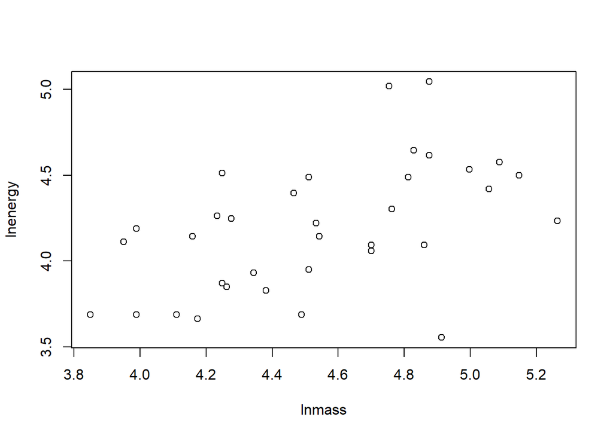

```r
#Example data
MoleRats<-read.csv("c:/Users/gjosg/Dropbox/R_Handbook_2020_UVic/Data/MoleRats.csv", header=TRUE)

MoleRats$caste<-factor(MoleRats$caste) #ensure my grouping variable is a factor for easier plotting

plot(lnenergy~lnmass, data=MoleRats) #basic scatterplot
```

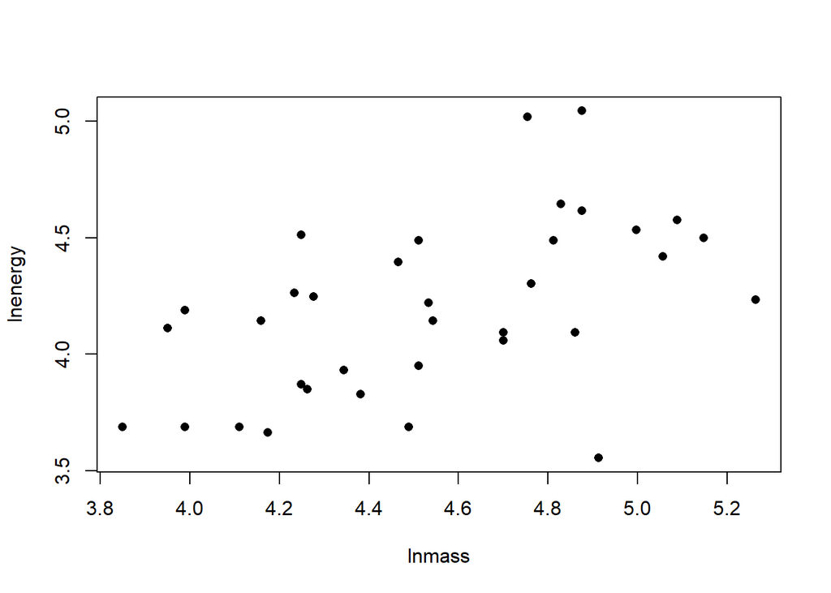

```r
plot(lnenergy~lnmass, data=MoleRats, pch=16) #pch changes point type. Try a few different numbers.
```

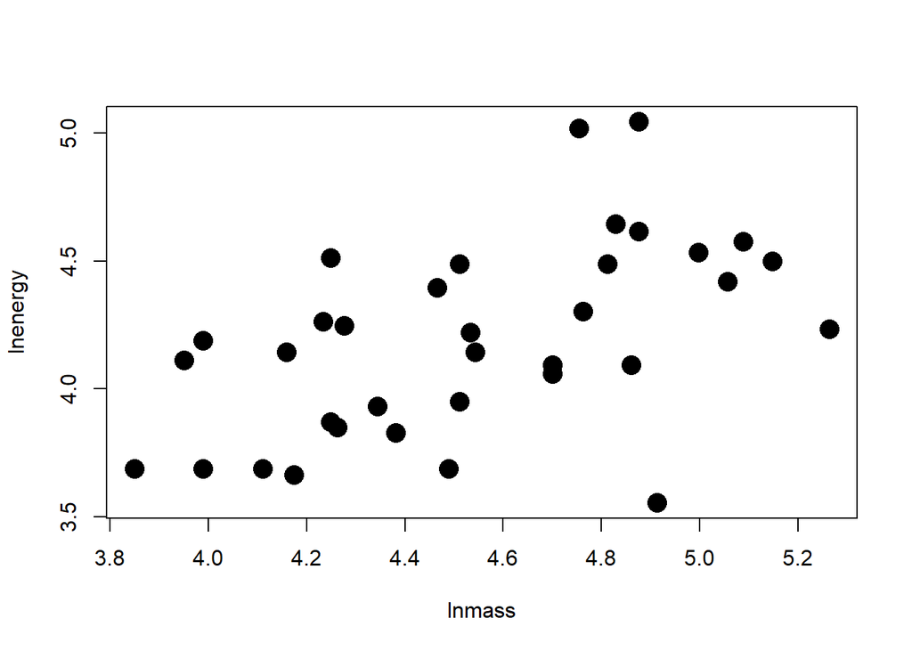

```r
plot(lnenergy~lnmass, data=MoleRats, pch=16, cex=2) #cex changes point size. Try a few different numbers.
```

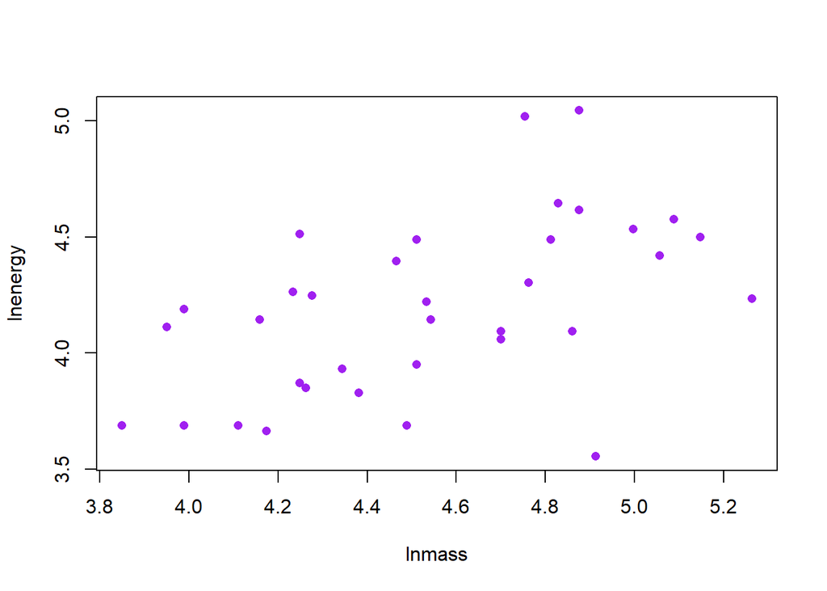

```r
plot(lnenergy~lnmass, data=MoleRats, pch=16, col="purple") #col changes colour
```

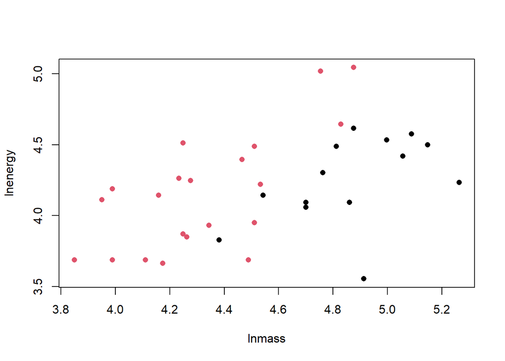

```r
plot(lnenergy~lnmass, data=MoleRats, pch=16, col=as.numeric(MoleRats$caste)) #col changes colour based on grouping variable
```

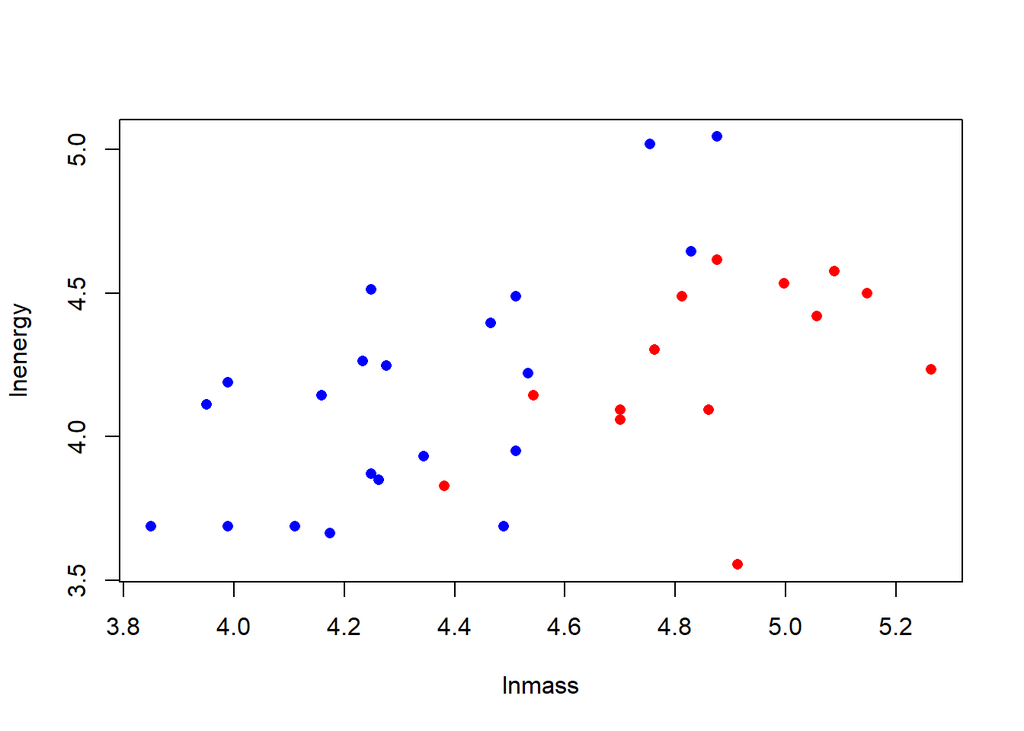

```r
####CUSTOM COLOURS#############

#Make your own vector of colours that will be referenced in the col argument.

colours<-c("red", "blue")#define colours you want to use

plot(lnenergy~lnmass, data=MoleRats, pch=16, col=colours[as.numeric(MoleRats$caste)]) #more customizable colour changes based on grouping variable. The first level is turned to a "1" and second level into a "2" by as.numeric, allowing me to get either the first colour or second colour of my object "colours" depending on the group (ie lazy or worker caste).
```

### Change axes and boxes around plots

TO customize what labels are show, use the labels and at arguments. The labels argument specifies the labels, and the at argument specifies where along the axis you want to put the labels. They must be the same length (ie you cannot have more labels than places where you want to put the labels).

Use las=2 to flip axis labels 90 degrees. You can use las=2 directly in the plot() function, but it will flip BOTH the x- and y-axis. Often, you just want to flip the y-axis, so I suppress it with yaxt=“n” and remake it with axis(2, las=2). See example in the code chunk below.

Use ylim and xlim arguments in the plot() function change y-axis and x-axis limits, respectively

Use ylab and xlab arguments in the plot() function change y-axis and x-axis titles, respectively (another way is to use mtext below).

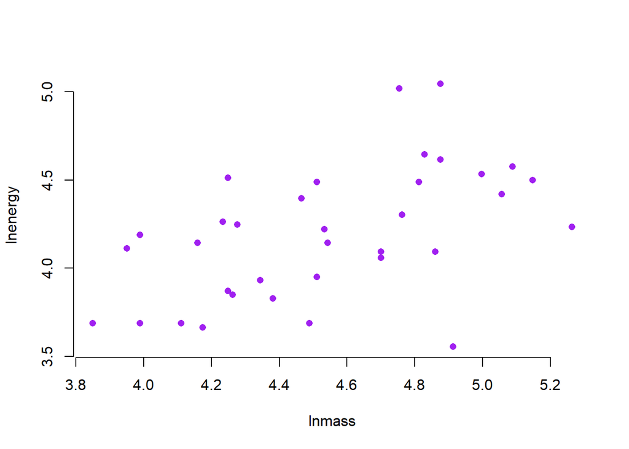

```r
#Remove boxes around a plot:

plot(lnenergy~lnmass, data=MoleRats, pch=16, col="purple", bty="n") #bty="n" removes box around the plot
```

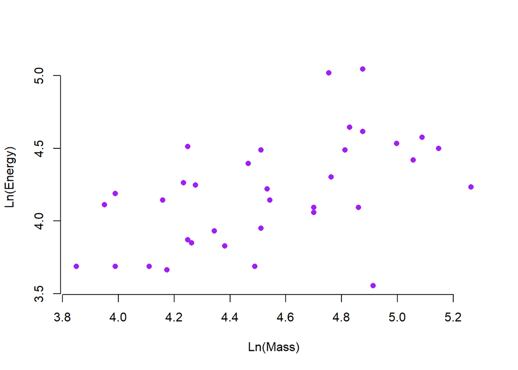

```r
#Add axis titles
plot(lnenergy~lnmass, data=MoleRats, pch=16, col="purple", bty="n", ylab="Ln(Energy)", xlab="Ln(Mass)")
```

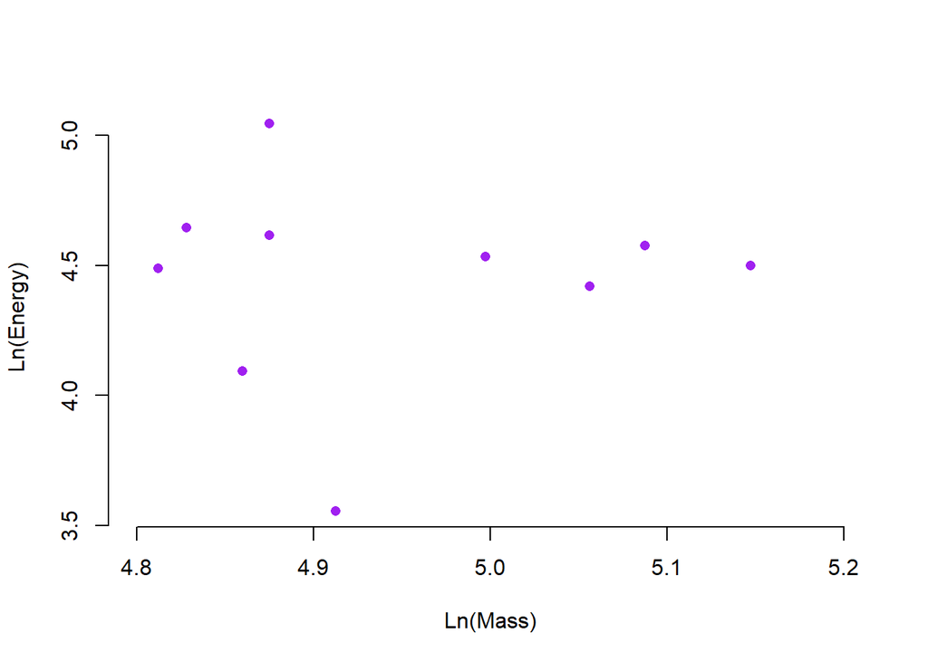

```r
#Change axis limits
plot(lnenergy~lnmass, data=MoleRats, pch=16, col="purple", bty="n", ylab="Ln(Energy)", xlab="Ln(Mass)", xlim=c(4.8,5.2)) #this limits the plot to between 4.8 and 5.2 on the x-axis
```

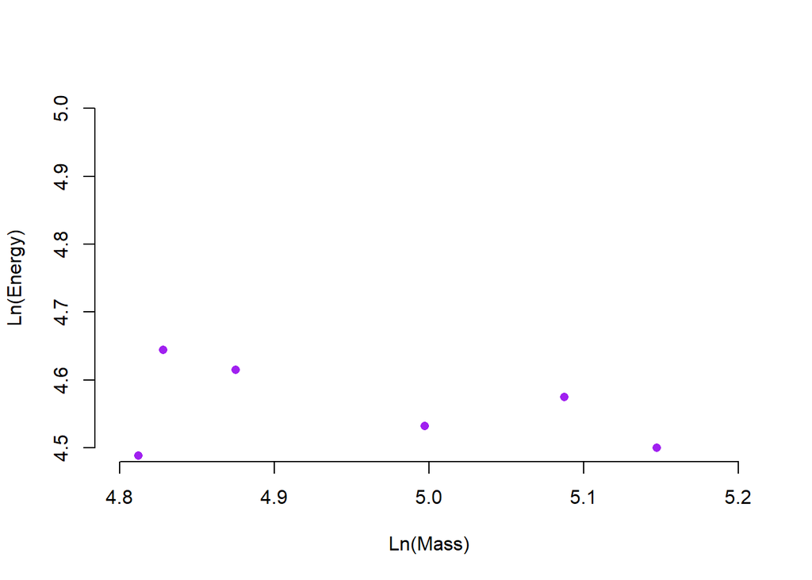

```r
plot(lnenergy~lnmass, data=MoleRats, pch=16, col="purple", bty="n", ylab="Ln(Energy)", xlab="Ln(Mass)", xlim=c(4.8,5.2), ylim=c(4.5,5.0)) #this further limits the plot to between 4.5 and 5.0 on the y-axis
```

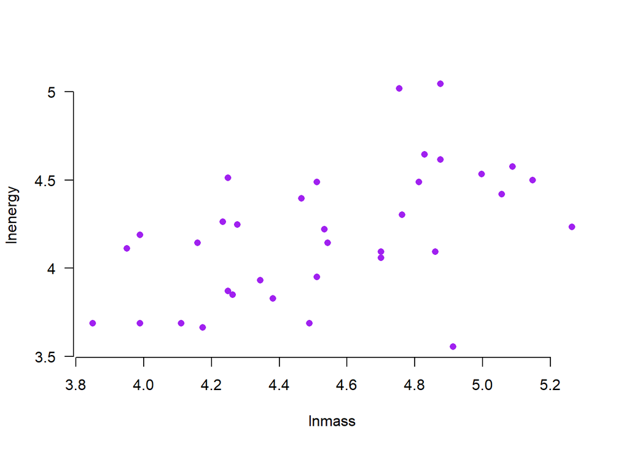

```r
#Remove and substitute axes:
plot(lnenergy~lnmass, data=MoleRats, pch=16, col="purple", bty="n", yaxt="n") #yaxt="n" removes the y-axis
axis(2, labels=seq(3.5,5.0,0.5), at=seq(3.5,5.0,0.5), las=2) #adds the y-axis back (x-axis is "1", y-axis is "2"). seq goes from first number to second number in units of third number. las=2 turns the numbers of the axis ninety degrees. The specified labels are put in the positions along the axis specified by the at= argument.
```

### Add horizontal, vertical, regression lines

abline adds lines to a plot. Use h for a horizontal line and v for a vertical line. To a regression line, place the regression object (see regression below) the abline().

lwd changes the thickness of a line (higher numbers are thicker) lty changes the type of line (eg 2 is dashed). Examples: http://www.sthda.com/english/wiki/line-types-in-r-lty

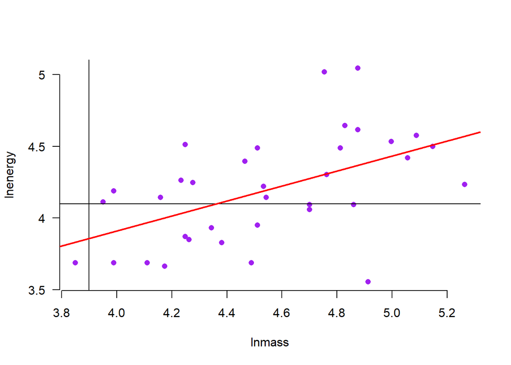

```r
plot(lnenergy~lnmass, data=MoleRats, pch=16, col="purple", bty="n", yaxt="n")
axis(2, labels=seq(3.5,5.0,0.5), at=seq(3.5,5.0,0.5), las=2)
abline(h=4.1) #adds horizontal line at x=4.1
abline(v=3.9) #adds vertical line at y=3.9
abline(lm(lnenergy~lnmass, data=MoleRats), col="red", lwd=2) #adds red regression line. Use lwd to change line thickness
```

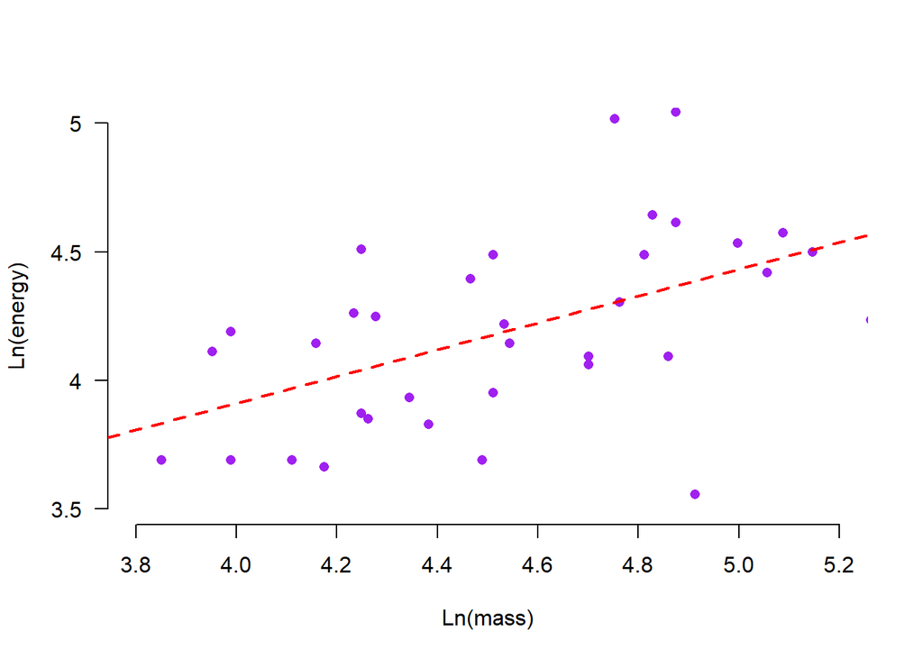

```r
plot(lnenergy~lnmass, data=MoleRats, pch=16, col="purple", bty="n", yaxt="n", ylab="Ln(energy)", xlab="Ln(mass)", ylim=c(3.5,5), xlim=c(3.8,5.2)) #Use ylab and xlab to change y- and x-axis titles, respectively. Use ylim and xlim to change y- and x-axis limits (min, max) respectively.
axis(2, labels=seq(3.5,5.0,0.5), at=seq(3.5,5.0,0.5), las=2)
abline(lm(lnenergy~lnmass, data=MoleRats), col="red", lwd=2, lty=2) #Use lty to change line type (1 is normal, 2 is dotted - try other numbers)
```

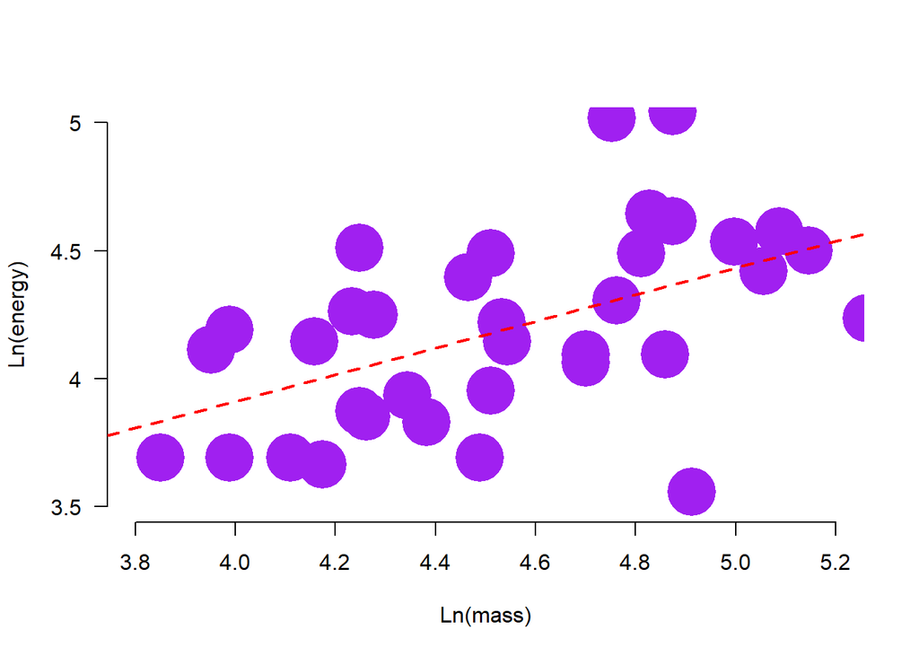

```r
#Use cex to change the size of elements
plot(lnenergy~lnmass, data=MoleRats, pch=16, col="purple", bty="n", yaxt="n", ylab="Ln(energy)", xlab="Ln(mass)", ylim=c(3.5,5), xlim=c(3.8,5.2), cex=5) #cex changes size of points
axis(2, labels=seq(3.5,5.0,0.5), at=seq(3.5,5.0,0.5), las=2)
abline(lm(lnenergy~lnmass, data=MoleRats), col="red", lwd=2, lty=2)
```

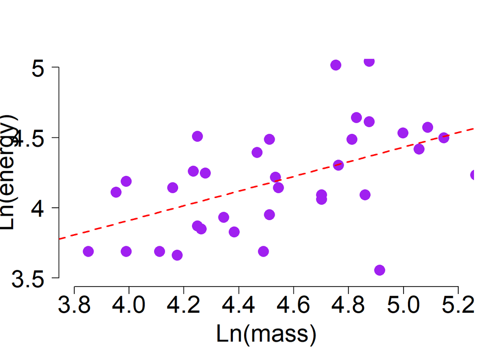

```r
plot(lnenergy~lnmass, data=MoleRats, pch=16, col="purple", bty="n", yaxt="n", ylab="Ln(energy)", xlab="Ln(mass)", ylim=c(3.5,5), xlim=c(3.8,5.2), cex=2, cex.axis=2, cex.lab=2) #cex.axis changes size of labels on axes. NOTE: if have axis() function, need to add it there for that axis. cex.lab changes size of axis titles.
axis(2, labels=seq(3.5,5.0,0.5), at=seq(3.5,5.0,0.5), las=2, cex.axis=2)
abline(lm(lnenergy~lnmass, data=MoleRats), col="red", lwd=2, lty=2)
```

### Line plot

If you want lines instead of points, remove pch and add type=“l” to your plot.

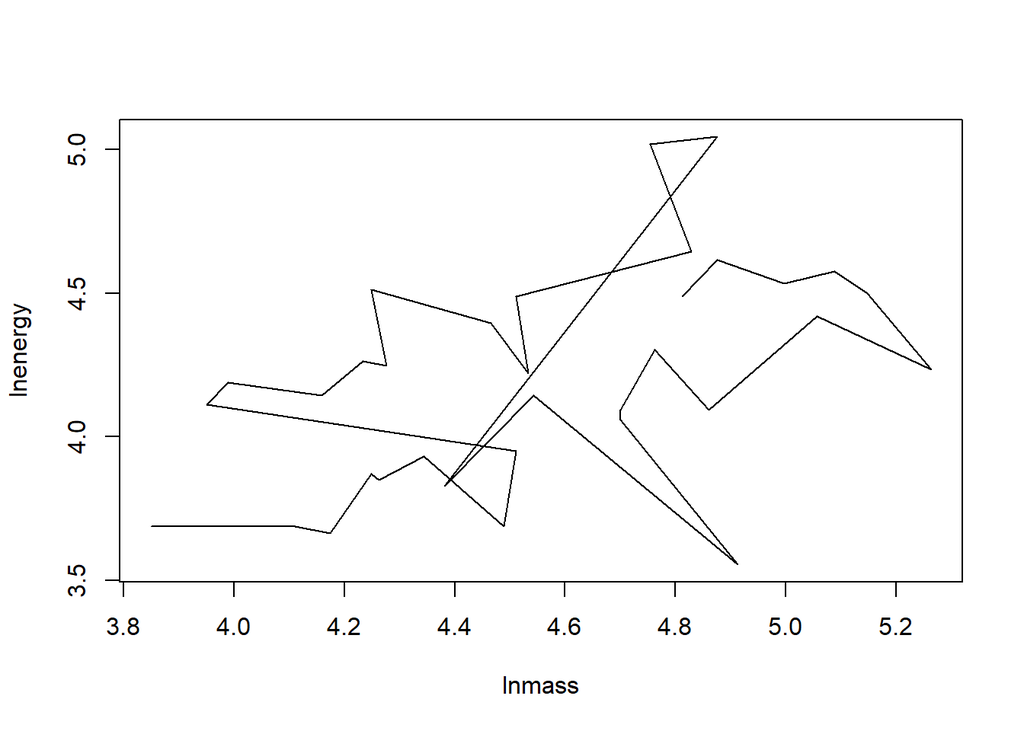

```r
plot(lnenergy~lnmass, data=MoleRats, type="l")
```

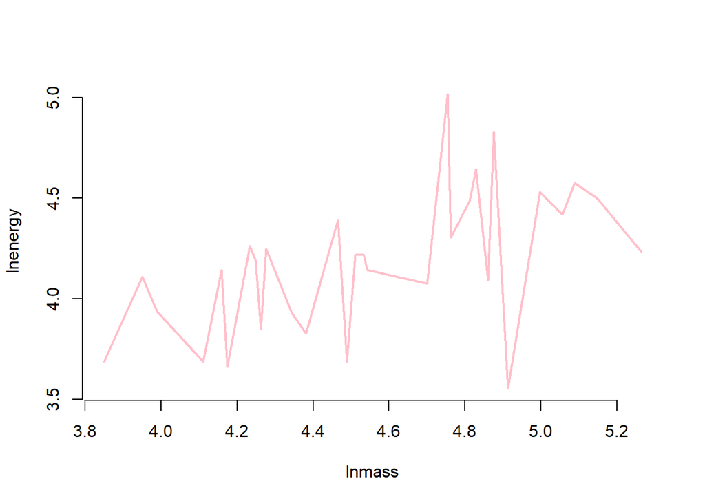

```r
#As you can see this does not work well with multiple points at each value of x.

#A line plot of averages:
means.rat<-aggregate(lnenergy~lnmass, data=MoleRats, mean)

plot(lnenergy~lnmass, data=means.rat, type="l", col="pink", lwd=2, bty="n")
```

```r
#use col to change colour, lwd to change line thickness, lty to change line type
```